# How to be civil about political loss – The importance of good loser messages

Supporting Information

2020-08-04

# 1 Preface

This is the Supplementary Material for the manuscript entitled *How to be civil about political loss – The importance of good loser messages*.

We pre-registered Study 2 and Study 3 at aspredicted.org.

When not otherwise stated, we followed the pre-registration.

# 2 (PART) STUDY I

The experiment for Study I was fielded in Sweden in the fall of 2017 and spring of 2018 as an add-on to the fifth wave of the European Values Survey (EVS, PI Susanne Wallman Lundåsen). EVS is based on a probability sample of the Swedish population age 18 or older (n = 1194). Interviews were face-to-face. The fieldwork organization was IPSOS, Sweden. For a detailed documentation we refer to https://europeanvaluesstudy.eu/methodology-data-documentation/. Study 1 was one of three experiments included in a paper and pencil leave behind. The return rate of the questionnaire was 85% (n =1019).

# 3 Pre-treatment measures and experimental vignette

The statistics are displayed for the respondents of interest in this study, which is the respondents who end up with observing an unfavorable decision outcome in the experiment.

## 3.1 Pre-treatment measures

### 3.1.1 Ban on begging - opinion

(#tab:1031_pre_begging)What is your opinion on a ban on begging in your municipality?

| Value | N | Percent |
| --- | --- | --- |
| Against ban | 215 | 45 |
| For ban | 266 | 55 |

### 3.1.2 Ban on begging - importance

(#tab:1031_pre_begging2)How important is the issue of ban on begging to you personally?

| Value | N | Percent |
| --- | --- | --- |
| 1 Not important at all | 37 | 8 |
| 2 | 72 | 15 |
| 3 | 76 | 16 |
| 4 | 103 | 21 |
| 5 | 83 | 17 |
| 6 | 55 | 11 |
| 7 Very important | 55 | 11 |

The mean score for the pre treatment measure “How important is the issue of ban on begging to you personally?” is 4.06, and the standard deviation is 1.76.

## 3.2 Experimental vignette

*Experimental vignette.*

> Imagine that your municipality is about to decide whether begging on the streets should be banned or allowed within the municipal borders. The decision can be made in different ways: One option is that the local political representatives make the decision. Another option is that the citizens of the municipality decide through a referendum. Please image how you would react if this scenario occurred in your municipality: After a debate in the media, the local political representatives decide to ban begging in the municipality. *Treatment text follows.*

(#tab:1031_vignette)Vignette treatments and texts, Swedish vignette experiment

| Treatment | Text |
| --- | --- |
| No prime | Imagine that your municipality is about to decide whether begging on the streets should be banned or allowed within the municipal borders. The decision can be made in different ways: One option is tha… |
| Lamenting politician | Imagine that your municipality is about to decide whether begging on the streets should be banned or allowed within the municipal borders. The decision can be made in different ways: One option is tha… |
| Generic good loser prime | Imagine that your municipality is about to decide whether begging on the streets should be banned or allowed within the municipal borders. The decision can be made in different ways: One option is tha… |

## 3.3 Post treatment measures

### 3.3.1 Fairness

(#tab:1031_outcome_measures_fairness)What do you think about the way the decision was made?

| Value | N | Percent |
| --- | --- | --- |
| 1 Not fair at all | 74 | 15 |
| 2 | 52 | 11 |
| 3 | 77 | 16 |
| 4 | 114 | 24 |
| 5 | 54 | 11 |
| 6 | 46 | 10 |
| 7 Very fair | 64 | 13 |

The mean score for the post treatment measure “What do you think about the way the decision was made?” is 3.86, and the standard deviation is 1.91.

# 4 Effects on losers

Treatment effects on experimental subjects who find the decision outcome to align unfavorably with their own preferences.

## 4.1 Fairness

In the manuscript, we mention that the Generic good loser message for the respondents with an unfavorable outcome is on par with the outcome favorability effect (difference in fairness perceptions between winners and losers). The table below displays the outcome favorability effect, and table ‘tab:1055_post_fairness’ further below displays the treatment effect of the Generic good loser message.

(#tab:1050_int_outfav)Conditional effect of outcome favorability on Generic good loser message treatment, Study 1

| Treatment value | Estimate | Std. Error | t-statistic | p value |
| --- | --- | --- | --- | --- |
| Intercept | 4.79 | 0.08 | 62.18 | 0 |
| Unfavorable outcome | -0.93 | 0.11 | -8.28 | 0 |

### 4.1.1 Fairness I

> Figure 2 in the manuscript:

(#tab:1055_post_fairness)Treatment effects on fairness perceptions of decision, Study 1

| Treatment value | Estimate | Std. Error | t-statistic | p value |
| --- | --- | --- | --- | --- |
| Not shown | 3.46 | 0.16 | 22.32 | 0.00 |
| Lamenting politician | 0.27 | 0.21 | 1.26 | 0.21 |
| Generic good loser message | 0.88 | 0.21 | 4.15 | 0.00 |

### 4.1.2 Fairness II

> Lamenting politician as reference category

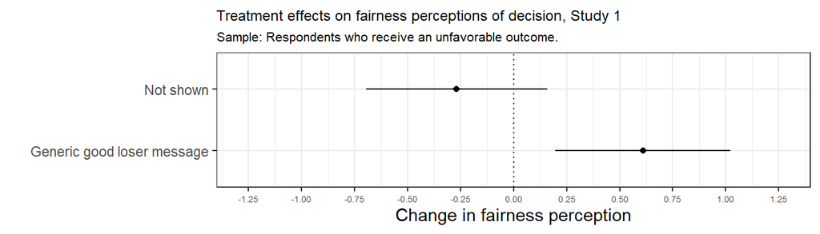

(#tab:105_post_fairness)Treatment effects on fairness perceptions of decision, Study 1

| Treatment value | Estimate | Std. Error | t-statistic | p value |
| --- | --- | --- | --- | --- |
| Intercept | 3.73 | 0.15 | 25.41 | 0.00 |
| Not shown | -0.27 | 0.21 | -1.26 | 0.21 |
| Generic good loser message | 0.61 | 0.21 | 2.96 | 0.00 |

Note:  
Lamenting politician set as reference category.

## 4.2 Willingness to accept

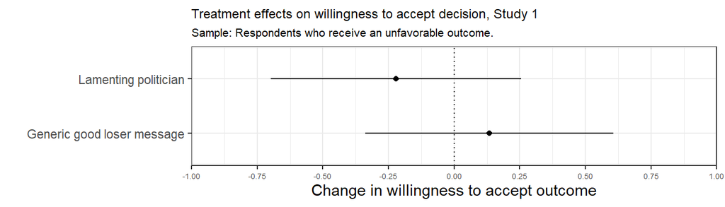

(#tab:105_post_accept)Treatment effects on willingness to accept decision, Study 1

| Treatment value | Estimate | Std. Error | t-statistic | p value |
| --- | --- | --- | --- | --- |
| Not shown | 4.31 | 0.17 | 24.95 | 0.00 |
| Lamenting politician | -0.22 | 0.24 | -0.93 | 0.35 |
| Generic good loser message | 0.13 | 0.24 | 0.57 | 0.57 |

# 5 (PART) STUDY II

The experiment for Study II was fielded in Norway during the spring and fall of 2017 during the 9th and 10th waves of [Norwegian Citizen Panel](https://www.uib.no/medborger). This is a research-purpose internet panel with over 6000 active participants. It is based on a probability sample of the general Norwegian population above the age of 18 drawn from the Norwegian National Registry. The survey is based on a online questionnaire with postal recruitment. Panel members complete a questionnaire three times a year of 15 minutes each. The survey panel is a core component of The Digital Social Science Core Facilities (DIGSSCORE), and was established in 2013 as a collaboration between several departments at the Faculty of Social Sciences at the University of Bergen and NORCE – Norwegian Research Centre. We refer to the documentation report for further details on technical aspects of the survey, panel recruitment, response rates of the 13th wave, and representativeness. For details about the data collected in this project and the survey panel at large, we refer to the codebook for the Waves 1-13.

# 6 Pre-treatment, vignette, post-treatment

The statistics are displayed for the respondents of interest in this study, which is the respondents who end up with observing an unfavorable decision outcome in the experiment.

## 6.1 Pre-treatment measures

### 6.1.1 Good loser norm I

(#tab:2031_pre1)What is your opinion – how important is it to accept the decisions about important social issues after they have been adopted?

| Value | N | Percent |
| --- | --- | --- |
| Not important at all | 9 | 1 |
| Slightly important | 46 | 4 |
| Somewhat important | 263 | 25 |
| Important | 577 | 56 |
| Very important | 110 | 11 |
| NA | 30 | 3 |

The mean score for the pre treatment measure “What is your opinion – how important is it to accept the decisions about important social issues after they have been adopted?” is 3.73, and the standard deviation is 0.75.

### 6.1.2 Good loser norm II

(#tab:2031_pre2)To what extent do you think people in Norway are willing to accept the decisions about important social issues after they have been adopted by politicians and the authorities?

| Value | N | Percent |
| --- | --- | --- |
| Not at all | 2 | 0 |
| Low degree | 39 | 4 |
| Some degree | 369 | 36 |
| High degree | 510 | 49 |
| Very high degree | 56 | 5 |
| NA | 59 | 6 |

The mean score for the pre treatment measure “To what extent do you think people in Norway are willing to accept the decisions about important social issues after they have been adopted by politicians and the authorities?” is 3.59, and the standard deviation is 0.67.

### 6.1.3 Good loser norm III

(#tab:2031_pre3)What about you personally – do you live up to this standard (i.e., accept the decisions about important social issues after they have been adopted by politicians and the authorities)?

| Value | N | Percent |
| --- | --- | --- |
| Not at all | 9 | 1 |
| Low degree | 33 | 3 |
| Some degree | 291 | 28 |
| High degree | 582 | 56 |
| Very high degree | 72 | 7 |
| NA | 48 | 5 |

The mean score for the pre treatment measure “What about you personally – do you live up to this standard (i.e., accept the decisions about important social issues after they have been adopted by politicians and the authorities)?” is 3.68, and the standard deviation is 0.7.

### 6.1.4 Ban on begging - opinion

(#tab:2031_pre4)What is your opinion on a ban on begging in your municipality?

| Value | N | Percent |
| --- | --- | --- |
|  | 17 | 2 |
| Anti | 326 | 31 |
| Pro | 692 | 67 |

### 6.1.5 Ban on begging - importance

(#tab:2031_pre5)How important is this issue to you personally?

| Value | N | Percent |
| --- | --- | --- |
| Not important at all | 57 | 6 |
| Slightly important | 350 | 34 |
| Somewhat important | 334 | 32 |
| Important | 195 | 19 |
| Very important | 77 | 7 |
| NA | 22 | 2 |

The mean score for the pre treatment measure “How important is this issue to you personally?” is 2.89, and the standard deviation is 1.03.

## 6.2 Experimental vignette

(#tab:2031_vignette)Video vignette treatment dimensions and values.

| Preference | Treatment | Text |
| --- | --- | --- |
| Pro ban on begging | No prime | The majority votes against a ban on begging. That means the council will not ban begging in your municipality. |
|  | Lamenting politician | The majority votes against a ban on begging. That means the council will not ban begging in your municipality. After the decision, the leader of one of the parties who where in favor of a ban states t… |
|  | Generic good loser prime | The majority votes against a ban on begging. That means the council will not ban begging in your municipality. After the decision, the leader of one of the parties who where in favor of a ban states t… |
|  | Specific good loser prime | The majority votes against a ban on begging. That means the council will not ban begging in your municipality. After the decision, the leader of one of the parties who where in favor of a ban states t… |
|  | Winner | The majority votes for a ban on begging. That means the council will ban begging in your municipality. |
| Against ban on begging | No prime | The majority votes for a ban on begging. That means the council will ban begging in your municipality. |
|  | Lamenting politician | The majority votes for a ban on begging. That means the council will ban begging in your municipality. After the decision, the leader of one of the parties who where in favor of a ban states that they… |
|  | Generic good loser prime | The majority votes for a ban on begging. That means the council will ban begging in your municipality. After the decision, the leader of one of the parties who where in favor of a ban states that they… |
|  | Specific good loser prime | The majority votes for a ban on begging. That means the council will ban begging in your municipality. After the decision, the leader of one of the partieswho where in favor of a ban states that they … |
|  | Winner | The majority votes against a ban on begging. That means the council will not ban begging in your municipality. |

<sup>1</sup> Intro to all respondents: Imagine that your municipality is about to decide whether begging on the streets should be banned or allowed within the municipal borders in the future. This is a controversial decision: Some inhabitants and politicians strongly support the ban, while other inhabitants and politicians are equally strongly against such a ban on begging. Some parties propose a ban on begging. The decision will be made in the municipal council, and follows the normal decision-making procedure. The proposal is first debated in the council, where all members are welcome to express their position and their arguments. The debate is public, and journalists are present to report on the debate. In the end, the politicians vote on the proposal.  
<sup>2</sup> Video voice over text (video was subtitled).

## 6.3 Post-measures

### 6.3.1 Fairness

(#tab:2031_exp_post1)Fairness: What do you think about the way the decision was made?

| Value | N | Percent |
| --- | --- | --- |
| Not at all fair | 17 | 2 |
| Not very fair | 36 | 3 |
| Quite fair | 136 | 13 |
| Fair | 576 | 56 |
| Very fair | 164 | 16 |
| NA | 106 | 10 |

The mean score for the post treatment measure “What do you think about the way the decision was made?” is 3.9, and the standard deviation is 0.8.

### 6.3.2 Acceptance

(#tab:2031_post2)Acceptance: When you think about the actual outcome of the decision, how willing are you to accept the decision?

| Value | N | Percent |
| --- | --- | --- |
| Not at all willing | 25 | 2 |
| Not very willing | 90 | 9 |
| Quite willing | 141 | 14 |
| Willing | 465 | 45 |
| Very willing | 114 | 11 |
| NA | 200 | 19 |

The mean score for the post treatment measure “When you think about the actual outcome of the decision, how willing are you to accept the decision?” is 3.66, and the standard deviation is 0.94.

### 6.3.3 Trust in politicians

(#tab:2031_post3)Trust in politicians: Based on what you saw in the video, how much confidence do you have in the politicians who made the decision?

| Value | N | Percent |
| --- | --- | --- |
| No trust at all | 18 | 2 |
| Low trust | 113 | 11 |
| Some trust | 406 | 39 |
| High trust | 325 | 31 |
| Very high trust | 35 | 3 |
| NA | 138 | 13 |

The mean score for the post treatment measure “Based on what you saw in the video, how much confidence do you have in the politicians who made the decision?” is 3.27, and the standard deviation is 0.81.

### 6.3.4 Recording check

(#tab:2031_post4)What was the recording like?

| Value | N | Percent |
| --- | --- | --- |
| I had both sound and images | 816 | 79 |
| I had images, but no sound | 112 | 11 |
| I had neither sound nor images | 68 | 7 |
| I had sound, but no images | 6 | 1 |
| Something else prevented me from playing the video | 22 | 2 |
| NA | 11 | 1 |

### 6.3.5 Manipulation check

(#tab:2031_post5)Proportion that correctly or incorrectly identify whether or not the decision outcome was in line with their own preferences.

| Value | N | Percent |
| --- | --- | --- |
| Correct | 658 | 64 |
| Do not know | 50 | 5 |
| Do not remember | 31 | 3 |
| Incorrect | 162 | 16 |
| NA | 134 | 13 |

# 7 Effects on losers

> Main effects with ITT sample of respondents who receive an unfavorable outcome.

## 7.1 Fairness

> Figure 3 in the manuscript:

(#tab:205_post_fairness)Treatment effects among losers on fairness perceptions of decision, Study 2

| Treatment value | Estimate | Std. Error | t-statistic | p value |
| --- | --- | --- | --- | --- |
| Not shown (Intercept) | 3.74 | 0.05 | 70.22 | 0.00 |
| Lamenting politician | 0.03 | 0.08 | 0.35 | 0.72 |
| Generic good loser message | 0.32 | 0.07 | 4.37 | 0.00 |
| Specific good loser message | 0.24 | 0.07 | 3.28 | 0.00 |

### 7.1.1 Fairness II

> Lamenting politician as reference category

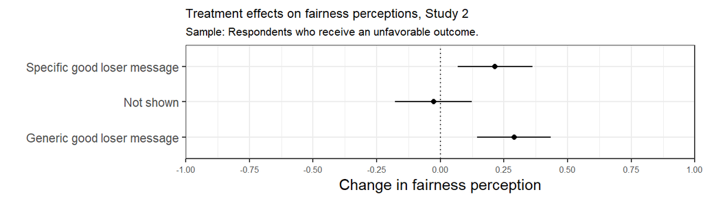

(#tab:2055_post_fairness)Treatment effects among losers on fairness perceptions of decision, Study 2

| Treatment value | Estimate | Std. Error | t-statistic | p value |
| --- | --- | --- | --- | --- |
| Intercept | 3.77 | 0.05 | 70.55 | 0.00 |
| Generic good loser message | 0.29 | 0.07 | 4.00 | 0.00 |
| Not shown | -0.03 | 0.08 | -0.35 | 0.72 |
| Specific good loser message | 0.21 | 0.07 | 2.92 | 0.00 |

### 7.1.2 Fairness moderated by issue importance

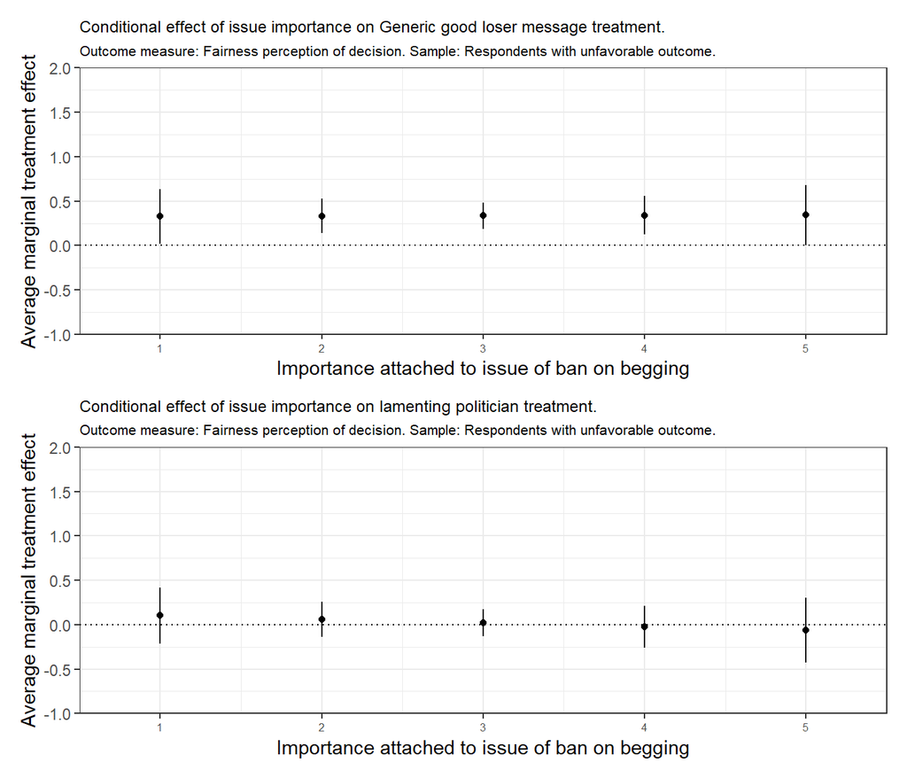

(#tab:2050_importance_treatment_fairness)Moderating effects of issue importance on experimental treatment, Study 2

| Factor | Issue importance | AME | SE | z-statistic | p value | Lower | Upper |
| --- | --- | --- | --- | --- | --- | --- | --- |
| Generic good loser message | 1 | 0.33 | 0.15 | 2.13 | 0.03 | 0.03 | 0.63 |
| Generic good loser message | 2 | 0.33 | 0.10 | 3.42 | 0.00 | 0.14 | 0.52 |
| Generic good loser message | 3 | 0.34 | 0.07 | 4.56 | 0.00 | 0.19 | 0.48 |
| Generic good loser message | 4 | 0.34 | 0.11 | 3.13 | 0.00 | 0.13 | 0.55 |
| Generic good loser message | 5 | 0.34 | 0.17 | 2.04 | 0.04 | 0.01 | 0.67 |
| Lamenting politician | 1 | 0.10 | 0.16 | 0.65 | 0.52 | -0.21 | 0.41 |
| Lamenting politician | 2 | 0.06 | 0.10 | 0.62 | 0.53 | -0.13 | 0.25 |
| Lamenting politician | 3 | 0.02 | 0.08 | 0.26 | 0.80 | -0.13 | 0.17 |
| Lamenting politician | 4 | -0.02 | 0.12 | -0.18 | 0.86 | -0.25 | 0.21 |
| Lamenting politician | 5 | -0.06 | 0.18 | -0.34 | 0.73 | -0.42 | 0.30 |

Note:  
Sample: Respondents with unfavorable outcome.

### 7.1.3 Fairness moderated by good loser norm

[figure not shown]

(#tab:2050_norm_treatment_fairness)Moderating effects of norm importance on experimental treatment, Study 2

| Factor | Norm importance | AME | SE | z-statistic | p value | Lower | Upper |
| --- | --- | --- | --- | --- | --- | --- | --- |
| Generic good loser message | 1 | 0.43 | 0.29 | 1.50 | 0.13 | -0.13 | 1.00 |
| Generic good loser message | 2 | 0.39 | 0.19 | 2.03 | 0.04 | 0.01 | 0.76 |
| Generic good loser message | 3 | 0.35 | 0.11 | 3.29 | 0.00 | 0.14 | 0.55 |
| Generic good loser message | 4 | 0.30 | 0.08 | 3.91 | 0.00 | 0.15 | 0.46 |
| Generic good loser message | 5 | 0.26 | 0.15 | 1.79 | 0.07 | -0.03 | 0.55 |
| Lamenting politician | 1 | -0.28 | 0.29 | -0.98 | 0.33 | -0.84 | 0.28 |
| Lamenting politician | 2 | -0.16 | 0.19 | -0.85 | 0.39 | -0.54 | 0.21 |
| Lamenting politician | 3 | -0.05 | 0.11 | -0.43 | 0.66 | -0.26 | 0.16 |
| Lamenting politician | 4 | 0.07 | 0.08 | 0.87 | 0.39 | -0.09 | 0.23 |
| Lamenting politician | 5 | 0.19 | 0.15 | 1.26 | 0.21 | -0.10 | 0.48 |

Note:  
Sample: Respondents with unfavorable outcome.

## 7.2 Willingnes to accept

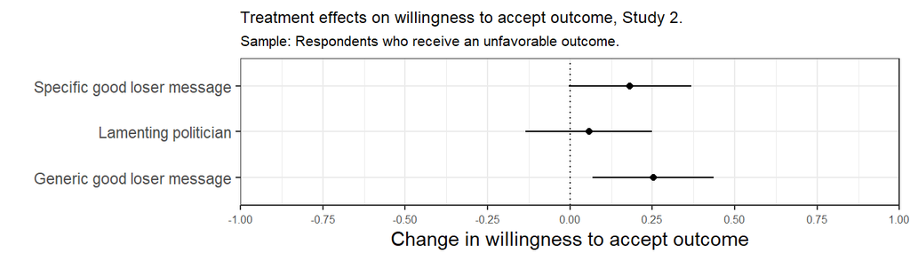

(#tab:205_post_accept)Treatment effects among losers on willingness to accept decision, Study 2

| Treatment value | Estimate | Std. Error | t-statistic | p value |
| --- | --- | --- | --- | --- |
| Not shown (Intercept) | 3.53 | 0.07 | 51.98 | 0.00 |
| Lamenting politician | 0.06 | 0.10 | 0.60 | 0.55 |
| Generic good loser message | 0.25 | 0.09 | 2.74 | 0.01 |
| Specific good loser message | 0.18 | 0.09 | 1.96 | 0.05 |

## 7.3 Trust in politician

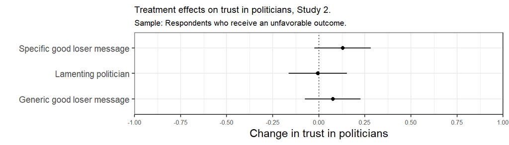

(#tab:205_post_trust)Treatment effects among losers on trust in politician, Study 2

| Treatment value | Estimate | Std. Error | t-statistic | p value |
| --- | --- | --- | --- | --- |
| Not shown (Intercept) | 3.22 | 0.06 | 57.66 | 0.00 |
| Lamenting politician | -0.01 | 0.08 | -0.07 | 0.94 |
| Generic good loser message | 0.08 | 0.08 | 1.00 | 0.32 |
| Specific good loser message | 0.13 | 0.08 | 1.68 | 0.09 |

## 7.4 Main effects with reduced sample

> Main effects with sample that excludes respondents who fail manipulation check

### 7.4.1 Fairness

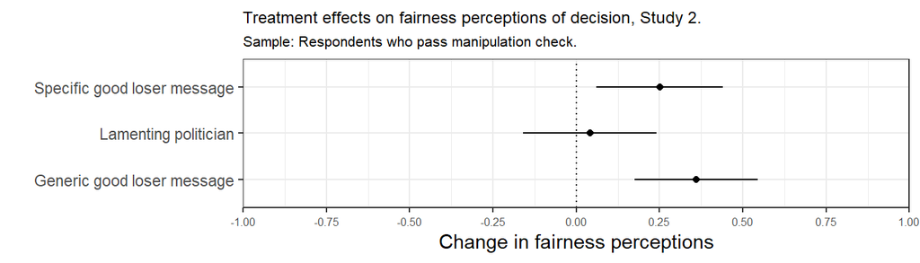

(#tab:2045_post_fairness)Treatment effects on fairness perceptions of decision, Study 2. Sample: Respondents who pass manipulation check

[output not shown]

### 7.4.2 Willingnes to accept

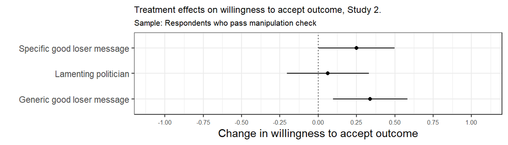

(#tab:2045_post_accept)Treatment effects on willingness to accept decision, Study 2. Sample: Respondents who pass manipulation check.

| Treatment value | Estimate | Std. Error | t-statistic | p value |
| --- | --- | --- | --- | --- |
| Not shown (Intercept) | 3.45 | 0.09 | 37.95 | 0.00 |
| Lamenting politician | 0.06 | 0.13 | 0.47 | 0.64 |
| Generic good loser message | 0.34 | 0.12 | 2.80 | 0.01 |
| Specific good loser message | 0.25 | 0.12 | 2.03 | 0.04 |

### 7.4.3 Trust in politician

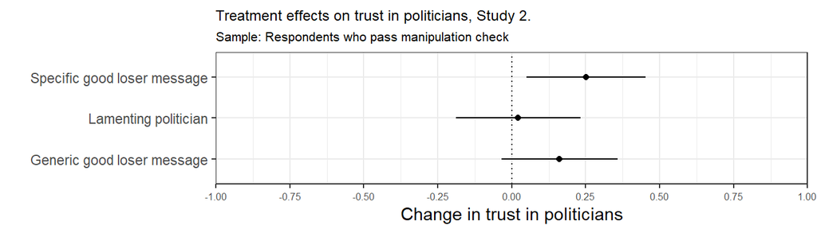

(#tab:2045_post_trust)Treatment effects on trust in politician, Study 2. Sample: Respondents who pass manipulation check.

| Treatment value | Estimate | Std. Error | t-statistic | p value |
| --- | --- | --- | --- | --- |
| Not shown (Intercept) | 3.17 | 0.07 | 42.71 | 0.00 |
| Lamenting politician | 0.02 | 0.11 | 0.21 | 0.83 |
| Generic good loser message | 0.16 | 0.10 | 1.65 | 0.10 |
| Specific good loser message | 0.25 | 0.10 | 2.49 | 0.01 |

# 8 (PART) STUDY III

The third study was also run online on a representative sample of adult Norwegians. We conducted a conjoint experiment with a rating assignment embedded in the 2018 fall wave of the Norwegian Citizen Panel.

The conjoint design allows us to explore scope conditions of findings. The advantage of conjoint designs, a method increasingly used in experimental political science research (Leeper, Hobolt, and Tilley 2020), is the possibility to include a large number of experimental treatments and estimate their effects simultaneously (Hainmueller, Hopkins, and Yamamoto 2014). The stimulus material for each respondent consists of randomly combined levels of the given features, resulting in sufficient observations for each feature while only a small share of the possible combinations is actually shown to participants. This enables us to include context variables into our design and to test our relationships of interest across a range of other factors that could potentially interfere with the treatment. As a result we gain insights into generalizability and robustness of our findings. Our conjoint design is presented as a text vignette with rating outcome measures like in studies 1 and 2. For similar applications in conjoint designs, see for example Huff and Kertzer (2018).

# 9 Pre-treatment, vignette, post-treatment

The statistics are displayed for the respondents of interest in this study, which is the respondents who end up with observing an unfavorable decision outcome in the experiment.

## 9.1 Pre-treatment measures

### 9.1.1 Ban on begging - opinion

(#tab:3031_pre1)What is your opinion on a ban on begging in your municipality?

| Value | N | Percent |
| --- | --- | --- |
| In favor | 836 | 60 |
| Oppose | 553 | 40 |
| NA | 5 | 0 |

### 9.1.2 Ban on begging - importance

(#tab:3031_pre2)How important is the issue of begging ban to you?

| Value | N | Percent |
| --- | --- | --- |
| Not important at all | 79 | 6 |
| Slightly important | 251 | 18 |
| Somewhat important | 447 | 32 |
| Important | 517 | 37 |
| Very important | 100 | 7 |

### 9.1.3 Toll on diesel cars - opinion

(#tab:3031_pre3)What is your opinion on an increase in the tolls for diesel cars in your municipality?

| Value | N | Percent |
| --- | --- | --- |
| In favor | 359 | 26 |
| Oppose | 1026 | 74 |
| NA | 9 | 1 |

### 9.1.4 Toll on diesel cars - importance

(#tab:3031_pre4)How important is the issue of increased tolls for diesel cars to you?

| Value | N | Percent |
| --- | --- | --- |
| Not important at all | 230 | 16 |
| Slightly important | 377 | 27 |
| Somewhat important | 382 | 27 |
| Important | 302 | 22 |
| Very important | 99 | 7 |
| NA | 4 | 0 |

The mean score for the pre treatment measure “How important is the issue of increased tolls for diesel cars to you?” is 3.24, and the standard deviation is 6.96.

## 9.2 Experimental vignette

Table 9.1: Vignette treatment dimensions and values

| Preference | Treatment | Text |
| --- | --- | --- |
| Issue | Ban on begging | in the future, begging on the streets will be banned or permitted in the municipality. This is a controversial decision. Some residents are strong in favour of a ban (the “Yes” side), while other resi… |
|  | Diesel car road toll | in the future, diesel cars will pay increased tolls. This is a controversial decision. Some residents are strongly in favour of such an increase (the side), while others are strongly against an increa… |
| Outcome | Yes | The Yes side won the vote |
|  | No | The No side won the vote |
| Winning margin | Not shown | . |
|  | Small margin | with a slight majority. |
|  | Large margin | with a large majority. |
| Winner’s gloating | Not shown |  |
|  | Yes | Following the decision, a politician on the winning side says that it was a good decision and that common sense prevailed. |
| Messenger and prime | Not shown |  |
|  | Politician, no prime | The leader of one of the parties that was against the decision says that they are disappointed and that the decision was wrong. |
|  | Politician, specific good loser prime | The leader of one of the parties that was against the decision says that they are disappointed and that the decision was wrong, but that it was a fair fight where both sides had the opportunity to arg… |
|  | Politician, generic good loser prime | The leader of one of the parties that was against the decision says that they are disappointed and that the decision was wrong, but that is what living in a democracy is all about. Sometimes you win, … |
|  | Newspaper, no prime | The local newspaper – which was against the decision – writes in an editorial that they are disappointed and that the decision was wrong. |
|  | Newspaper, specific good loser prime | The local newspaper – which was against the decision – writes in an editorial that they are disappointed and that the decision was wrong, but that it was a fair fight where both sides had the opportun… |
|  | Newspaper, generic good loser prime | The local newspaper – which was against the decision – writes in an editorial that they are disappointed and that the decision was wrong, but that is what living in a democracy is all about. Sometimes… |

Note:  
Experimental vignette (treatments in {curly brackets}): Below, we have described a hypothetical situation. Please read through the situation carefully and then answer the three questions that follow. Imagine that your municipality must decide on {Issue} The decision will be taken by the municipal council and follow the usual procedures. The proposal will initially be debated by the municipal council where all the members will have the opportunity to express their opinions and arguments regarding the issue. The debate will be public, and journalists will be in attendance to report on the debate. In the end, the politicians will vote on the issue. {Outcome} {[Winning margin} {Winner gloating} {Messenger and prime}

## 9.3 Post treatment measures

Please note that the the respondents were randomly assigned to either a worded answer scale, or a numbered answer scale. This accounts for the high share of NA’s in the post treatment distribution tables.

### 9.3.1 Evaluation

(#tab:3031_post1)What do you think about the way the decision was made?

| Value | N | Percent |
| --- | --- | --- |
| Not fair at all | 104 | 7 |
| Slightly fair | 417 | 30 |
| Somewhat fair | 110 | 8 |
| Fair | 61 | 4 |
| Very fair | 33 | 2 |
| NA | 669 | 48 |

(#tab:3031_post1)What do you think about the way the decision was made?

| Value | N | Percent |
| --- | --- | --- |
| 1 Not fair | 252 | 18 |
| 2 | 190 | 14 |
| 3 | 135 | 10 |
| 4 | 42 | 3 |
| 5 Most fair | 36 | 3 |
| NA | 739 | 53 |

The mean score for the pre treatment measure “What do you think about the way the decision was made?” is 48.71, and the standard deviation is 47.9 for the worded answer scale. For the numbered answer scale, the mean score is 52.44, and the standard deviation is 47.97

### 9.3.2 Acceptance

(#tab:3031_post3)When you think about the actual outcome of the decision, how willing are you to accept the decision?

| Value | N | Percent |
| --- | --- | --- |
| Not willing at all | 81 | 6 |
| Slightly willing | 345 | 25 |
| Somewhat willing | 159 | 11 |
| Willing | 106 | 8 |
| Very willing | 36 | 3 |
| NA | 667 | 48 |

(#tab:3031_post3)When you think about the actual outcome of the decision, how willing are you to accept the decision?

| Value | N | Percent |
| --- | --- | --- |
| 1 Not willing | 185 | 13 |
| 2 | 204 | 15 |
| 3 | 150 | 11 |
| 4 | 59 | 4 |
| 5 Most willing | 54 | 4 |
| NA | 742 | 53 |

The mean score for the pre treatment measure “When you think about the actual outcome of the decision, how willing are you to accept the decision?” is 48.71, and the standard deviation is 47.86 for the worded answer scale. For the numbered answer scale, the mean score is 52.61, and the standard deviation is 47.93

# 10 Effects on losers

Treatment effects on experimental subjects who find the decision outcome to align unfavorably with their own preferences (N = 1394)

## 10.1 Fairness perceptions

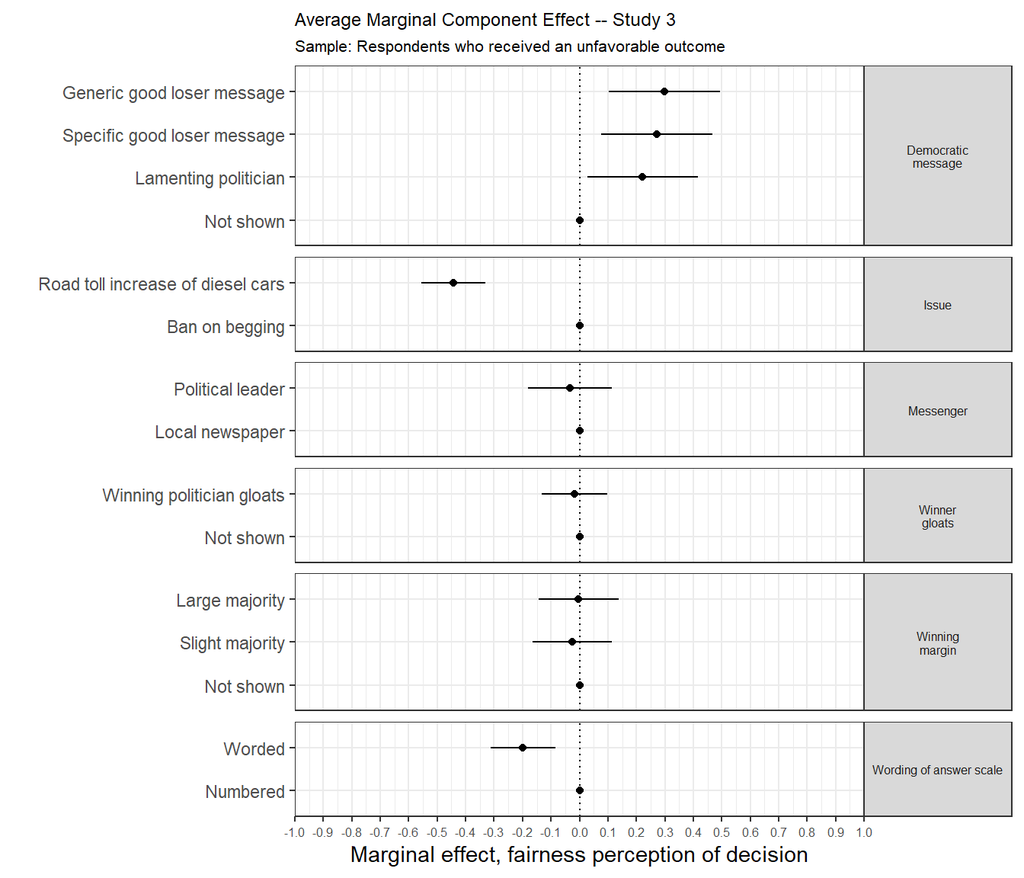

(#tab:305_post_fair_loser)Average Marginal Component Effect – Study 3

| Treatment value | Estimate | Std. Error | t-statistic | p value |
| --- | --- | --- | --- | --- |
| **Winning margin** |  |  |  |  |
| Not shown | 0.00 | 0.00 | NA | NA |
| Slight majority | -0.03 | 0.07 | -0.37 | 0.71 |
| Large majority | 0.00 | 0.07 | -0.04 | 0.97 |
| **Winner gloating** |  |  |  |  |
| Not shown | 0.00 | 0.00 | NA | NA |
| Winning politician gloats | -0.02 | 0.06 | -0.29 | 0.77 |
| **Good loser message** |  |  |  |  |
| Not shown | 0.00 | 0.00 | NA | NA |
| Lamenting politician | 0.22 | 0.10 | 2.28 | 0.02 |
| Specific good loser message | 0.27 | 0.10 | 2.79 | 0.01 |
| Generic good loser message | 0.30 | 0.10 | 3.04 | 0.00 |
| **Messenger** |  |  |  |  |
| Local newspaper | 0.00 | 0.00 | NA | NA |
| Political leader | -0.03 | 0.07 | -0.46 | 0.64 |
| **Issue** |  |  |  |  |
| Ban on begging | 0.00 | 0.00 | NA | NA |
| Road toll increase of diesel cars | -0.44 | 0.06 | -7.88 | 0.00 |
| **Wording of answer scale** |  |  |  |  |
| Numbered | 0.00 | 0.00 | NA | NA |
| Worded | -0.20 | 0.06 | -3.47 | 0.00 |

### 10.1.1 Conditional AMCEs

Issue importance

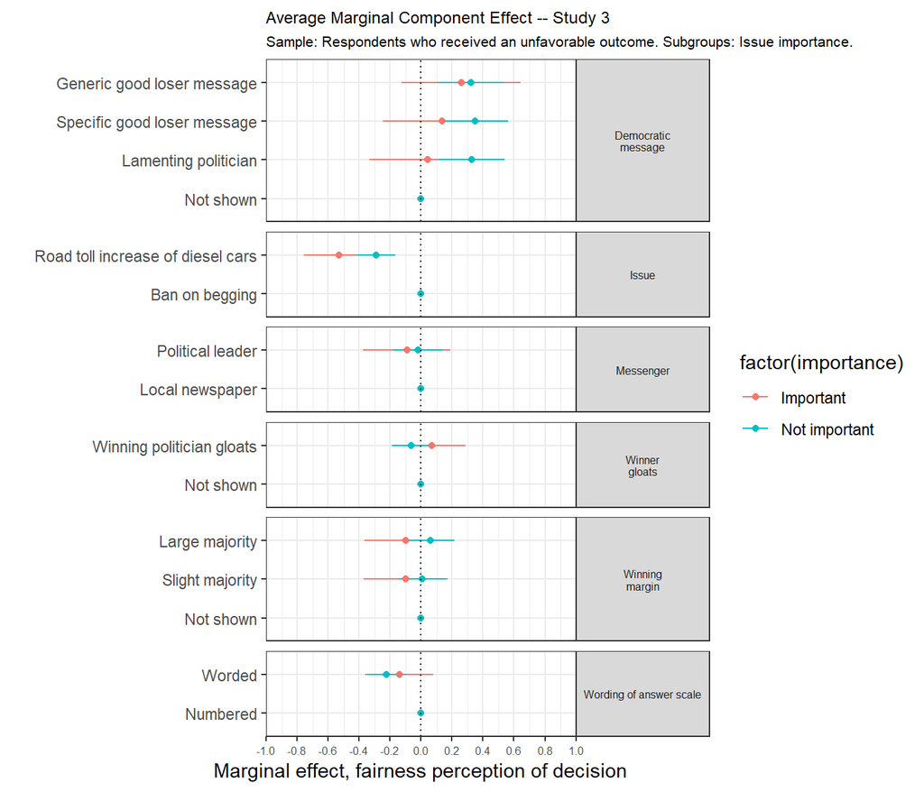

(#tab:306_post_fair_losers_intimportance)Average Marginal Component Effect – Study 3

| Treatment value | Estimate | Std. Error | t-statistic | p value | Issue importance |
| --- | --- | --- | --- | --- | --- |
| **Winning margin** |  |  |  |  |  |
| Not shown | 0.00 | 0.00 | NA | NA | Important |
| Slight majority | -0.10 | 0.13 | -0.73 | 0.46 | Important |
| Large majority | -0.10 | 0.13 | -0.73 | 0.47 | Important |
| Not shown | 0.00 | 0.00 | NA | NA | Not important |
| Slight majority | 0.01 | 0.08 | 0.11 | 0.91 | Not important |
| Large majority | 0.06 | 0.08 | 0.75 | 0.45 | Not important |
| **Winner gloating** |  |  |  |  |  |
| Not shown | 0.00 | 0.00 | NA | NA | Important |
| Winning politician gloats | 0.07 | 0.11 | 0.62 | 0.53 | Important |
| Not shown | 0.00 | 0.00 | NA | NA | Not important |
| Winning politician gloats | -0.06 | 0.06 | -0.98 | 0.33 | Not important |
| **Good loser message** |  |  |  |  |  |
| Not shown | 0.00 | 0.00 | NA | NA | Important |
| Lamenting politician | 0.04 | 0.19 | 0.23 | 0.82 | Important |
| Specific good loser message | 0.14 | 0.19 | 0.72 | 0.47 | Important |
| Generic good loser message | 0.26 | 0.19 | 1.35 | 0.18 | Important |
| Not shown | 0.00 | 0.00 | NA | NA | Not important |
| Lamenting politician | 0.33 | 0.11 | 3.09 | 0.00 | Not important |
| Specific good loser message | 0.35 | 0.11 | 3.30 | 0.00 | Not important |
| Generic good loser message | 0.32 | 0.11 | 3.04 | 0.00 | Not important |
| **Messenger** |  |  |  |  |  |
| Local newspaper | 0.00 | 0.00 | NA | NA | Important |
| Political leader | -0.09 | 0.14 | -0.65 | 0.51 | Important |
| Local newspaper | 0.00 | 0.00 | NA | NA | Not important |
| Political leader | -0.02 | 0.08 | -0.22 | 0.83 | Not important |
| **Issue** |  |  |  |  |  |
| Ban on begging | 0.00 | 0.00 | NA | NA | Important |
| Road toll increase of diesel cars | -0.53 | 0.11 | -4.73 | 0.00 | Important |
| Ban on begging | 0.00 | 0.00 | NA | NA | Not important |
| Road toll increase of diesel cars | -0.29 | 0.06 | -4.61 | 0.00 | Not important |
| **Wording of answer scale** |  |  |  |  |  |
| Numbered | 0.00 | 0.00 | NA | NA | Important |
| Worded | -0.14 | 0.11 | -1.28 | 0.20 | Important |
| Numbered | 0.00 | 0.00 | NA | NA | Not important |
| Worded | -0.22 | 0.06 | -3.53 | 0.00 | Not important |

Issue (ban on begging or road toll)

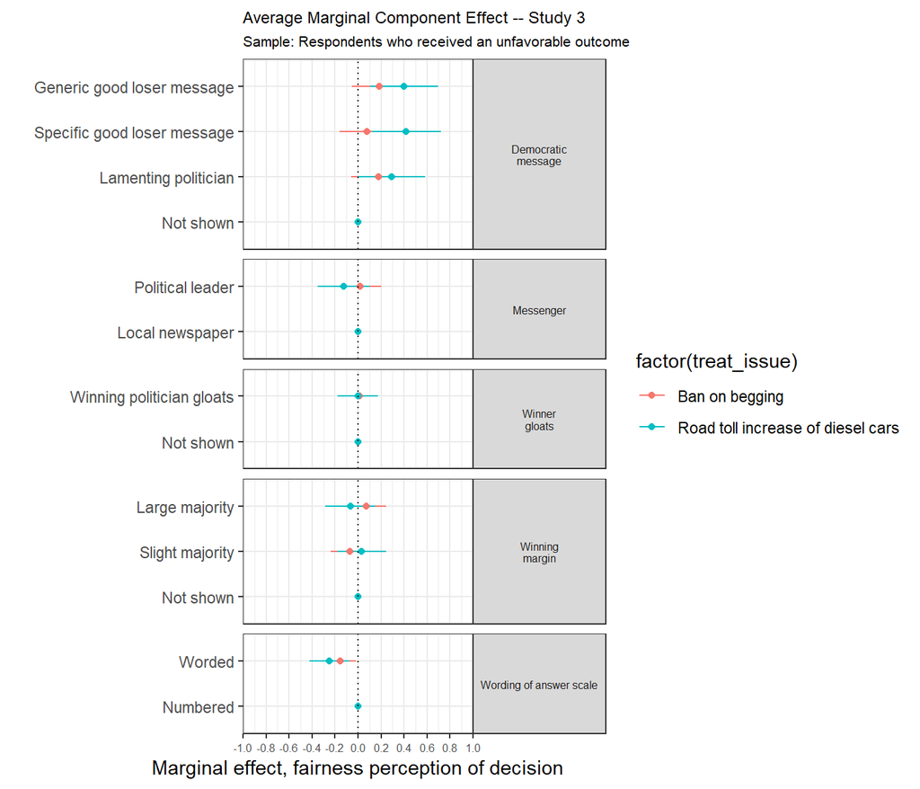

(#tab:305_post_fair_loser_issue)Average Marginal Component Effect – Study 3

[output not shown]

## 10.2 Willingnes to accept

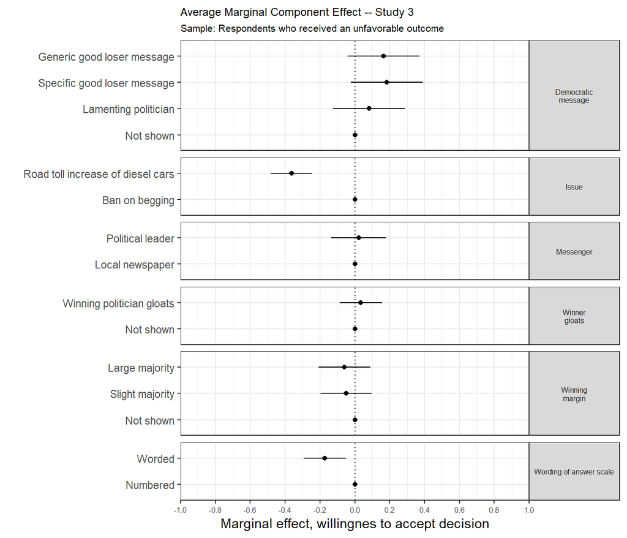

(#tab:305_post_accept_loser)Average Marginal Component Effects – Study 3

| Treatment value | Estimate | Std. Error | t-statistic | p value |
| --- | --- | --- | --- | --- |
| **Winning margin** |  |  |  |  |
| Not shown | 0.00 | 0.00 | NA | NA |
| Slight majority | -0.05 | 0.07 | -0.68 | 0.50 |
| Large majority | -0.06 | 0.07 | -0.80 | 0.42 |
| **Winner gloating** |  |  |  |  |
| Not shown | 0.00 | 0.00 | NA | NA |
| Winning politician gloats | 0.03 | 0.06 | 0.57 | 0.57 |
| **Good loser message** |  |  |  |  |
| Not shown | 0.00 | 0.00 | NA | NA |
| Lamenting politician | 0.08 | 0.10 | 0.80 | 0.43 |
| Specific good loser message | 0.18 | 0.10 | 1.78 | 0.08 |
| Generic good loser message | 0.16 | 0.10 | 1.60 | 0.11 |
| **Messenger** |  |  |  |  |
| Local newspaper | 0.00 | 0.00 | NA | NA |
| Political leader | 0.02 | 0.08 | 0.28 | 0.78 |
| **Issue** |  |  |  |  |
| Ban on begging | 0.00 | 0.00 | NA | NA |
| Road toll increase of diesel cars | -0.36 | 0.06 | -6.08 | 0.00 |
| **Wording of answer scale** |  |  |  |  |
| Numbered | 0.00 | 0.00 | NA | NA |
| Worded | -0.17 | 0.06 | -2.84 | 0.00 |

# 11 Outcome favorability effect across the three experiments

> Figure 1 in the manuscript:

(#tab:402_outfav_fair)The outcome favorability effect in three experiments

[output not shown]

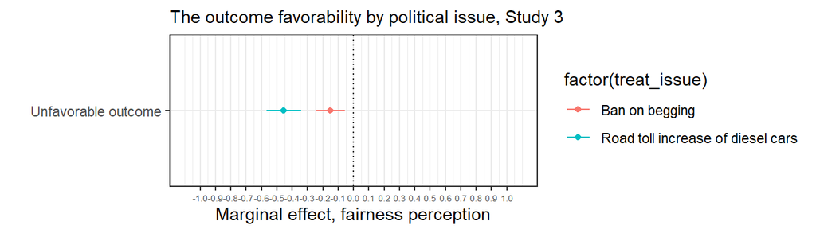

(#tab:4044_outfav_issue)The outcome favorability effect in three experiments

| Treatment value | Estimate | Std. Error | t-statistic | p value | Issue |
| --- | --- | --- | --- | --- | --- |
| Unfavorable outcome | -0.15 | 0.05 | -3.18 | 0 | Ban on begging |
| Unfavorable outcome | -0.45 | 0.06 | -7.97 | 0 | Road toll increase of diesel cars |

# References

Hainmueller, Jens, Daniel J Hopkins, and Teppei Yamamoto. 2014. “Causal Inference in Conjoint Analysis: Understanding Multidimensional Choices via Stated Preference Experiments.” *Political Analysis* 22 (1): 1–30.

Huff, Connor, and Joshua D Kertzer. 2018. “How the Public Defines Terrorism.” *American Journal of Political Science* 62 (1): 55–71.

Leeper, Thomas J, Sara B Hobolt, and James Tilley. 2020. “Measuring Subgroup Preferences in Conjoint Experiments.” *Political Analysis* 28 (2): 207–21.